# Week 8 Exerices

## Probability density functions

```python
from __future__ import print_function, division

%matplotlib inline

import numpy as np

import brfss

import thinkstats2
import thinkplot
```

```python
a_list = [1,2,3,4,5]
another_list = ["a","b","c","d","e"]

a_power_list = [value ** 2 for value in a_list]
print("--------------",a_power_list,"--------------")
filter_even_number = [value**2 for value in a_list if value % 2 == 0]
print("--------------",filter_even_number,"--------------")
print(zip(a_list, another_list))
a_dict = {key:value for value, key in zip(a_list, another_list)}
print("--------------",a_dict,"--------------")
```

```
-------------- [1, 4, 9, 16, 25] --------------
-------------- [4, 16] --------------
<zip object at 0x0FB91B70>
-------------- {'a': 1, 'b': 2, 'c': 3, 'd': 4, 'e': 5} --------------
```

I'll start with the data from the BRFSS again.  
If you get Error such as CDBRFS08.ASC.gz not found get this and download data https://github.com/AllenDowney/ThinkBayes2/blob/master/code/CDBRFS08.ASC.gz

```python
df = brfss.ReadBrfss()
```

```python
df.head(20)
```

|  | age | sex | wtyrago | finalwt | wtkg2 | htm3 |
| --- | --- | --- | --- | --- | --- | --- |
| 0 | 82.0 | 2 | 76.363636 | 185.870345 | 70.91 | 157.0 |
| 1 | 65.0 | 2 | 72.727273 | 126.603027 | 72.73 | 163.0 |
| 2 | 48.0 | 2 | NaN | 181.063210 | NaN | 165.0 |
| 3 | 61.0 | 1 | 73.636364 | 517.926275 | 73.64 | 170.0 |
| 4 | 26.0 | 1 | 88.636364 | 1252.624630 | 88.64 | 185.0 |
| 5 | 42.0 | 1 | 118.181818 | 415.161314 | 109.09 | 183.0 |
| 6 | 40.0 | 2 | 50.000000 | 422.810541 | 50.00 | 157.0 |
| 7 | 24.0 | 2 | 131.818182 | 1280.585980 | 122.73 | 178.0 |
| 8 | 37.0 | 1 | 87.727273 | 1245.060440 | 90.00 | 178.0 |
| 9 | 65.0 | 1 | 77.272727 | 382.738158 | 77.27 | 173.0 |
| 10 | 28.0 | 1 | 52.272727 | 3131.561570 | 63.64 | 170.0 |
| 11 | 68.0 | 2 | 86.363636 | 506.412109 | 78.18 | 168.0 |
| 12 | 40.0 | 2 | 62.727273 | 422.810541 | 62.73 | 175.0 |
| 13 | 49.0 | 1 | 127.272727 | 274.170333 | 127.27 | 183.0 |
| 14 | 24.0 | 2 | 95.454545 | 2561.171960 | 95.45 | 175.0 |
| 15 | 49.0 | 2 | 88.636364 | 181.063210 | 88.64 | 157.0 |
| 16 | 36.0 | 2 | 113.636364 | 211.405271 | 90.91 | 168.0 |
| 17 | 48.0 | 2 | NaN | 181.063210 | 50.00 | 155.0 |
| 18 | 65.0 | 2 | 100.000000 | 253.206055 | 100.00 | 160.0 |
| 19 | 75.0 | 2 | 72.727273 | 185.870345 | 72.73 | 165.0 |

Here are the mean and standard deviation of female height in cm.

```python
female = df[df.sex==2]
female_heights = female.htm3.dropna()
mean, std = female_heights.mean(), female_heights.std()
mean, std
```

```
(163.22347500412215, 7.269156286642232)
```

`NormalPdf` returns a Pdf object that represents the normal distribution with the given parameters.

`Density` returns a probability density, which doesn't mean much by itself.

```python
pdf = thinkstats2.NormalPdf(mean, std)
pdf.Density(mean + std)
#Density, which takes a value, x, and returns the density of the distribution at x.
```

```
0.03328731904743708
```

`thinkplot` provides `Pdf`, which plots the probability density with a smooth curve.

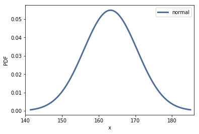

```python
thinkplot.Pdf(pdf, label='normal')
thinkplot.Config(xlabel='x', ylabel='PDF', xlim=[140, 186])
```

`Pdf` provides `MakePmf`, which returns a `Pmf` object that approximates the `Pdf`.

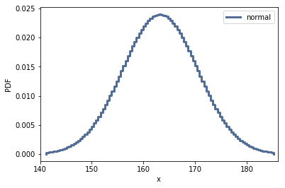

```python
#MakePmf, which evaluates Density at a discrete set of values and returns a normalized Pmf that approximates the Pdf.
pmf = pdf.MakePmf()
thinkplot.Pmf(pmf, label='normal')
thinkplot.Config(xlabel='x', ylabel='PDF', xlim=[140, 186])
```

If you have a `Pmf`, you can also plot it using `Pdf`, if you have reason to think it should be represented as a smooth curve.

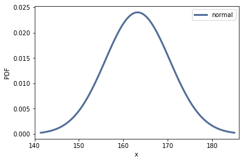

```python
thinkplot.Pdf(pmf, label='normal')
thinkplot.Config(xlabel='x', ylabel='PDF', xlim=[140, 186])
```

Using a sample from the actual distribution, we can estimate the PDF using Kernel Density Estimation (KDE).

If you run this a few times, you'll see how much variation there is in the estimate.

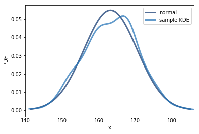

```python
thinkplot.Pdf(pdf, label='normal')

sample = np.random.normal(mean, std, 500)
sample_pdf = thinkstats2.EstimatedPdf(sample, label='sample')
thinkplot.Pdf(sample_pdf, label='sample KDE')
thinkplot.Config(xlabel='x', ylabel='PDF', xlim=[140, 186])
```

## Moments

Raw moments are just sums of powers.

```python
def RawMoment(xs, k):
    return sum(x**k for x in xs) / len(xs)
```

The first raw moment is the mean. The other raw moments don't mean much.

```python
RawMoment(female_heights, 1), RawMoment(female_heights, 2), RawMoment(female_heights, 3)
```

```
(163.22347500412215, 26694.74321809659, 4374411.46250422)
```

```python
def Mean(xs):
    return RawMoment(xs, 1)

Mean(female_heights)
```

```
163.22347500412215
```

The central moments are powers of distances from the mean.

```python
def CentralMoment(xs, k):
    mean = RawMoment(xs, 1)
    sum_list = [(x - mean)**k for x in xs]
    return sum(sum_list) / len(sum_list)
```

The first central moment is approximately 0. The second central moment is the variance.

```python
CentralMoment(female_heights, 1), CentralMoment(female_heights, 2), CentralMoment(female_heights, 3)
```

```
(-9.903557940122168e-14, 52.84042567529328, -46.88569506887073)
```

```python
def Var(xs):
    return CentralMoment(xs, 2)

Var(female_heights)
```

```
52.84042567529328
```

The standardized moments are ratios of central moments, with powers chosen to make the dimensions cancel.

```python
def StandardizedMoment(xs, k):
    var = CentralMoment(xs, 2)
    std = np.sqrt(var)
    return CentralMoment(xs, k) / std**k
```

The third standardized moment is skewness.

```python
StandardizedMoment(female_heights, 1), StandardizedMoment(female_heights, 2), StandardizedMoment(female_heights, 3)
```

```
(-1.3624108479155668e-14, 1.0, -0.1220649274510512)
```

```python
def Skewness(xs):
    return StandardizedMoment(xs, 3)

Skewness(female_heights)
```

```
-0.1220649274510512
```

Normally a negative skewness indicates that the distribution has a longer tail on the left. In that case, the mean is usually less than the median.

```python
def Median(xs):
    cdf = thinkstats2.Cdf(xs)
    return cdf.Value(0.5)
```

But in this case the mean is greater than the median, which indicates skew to the right.

```python
Mean(female_heights), Median(female_heights)
```

```
(163.22347500412215, 163.0)
```

Because the skewness is based on the third moment, it is not robust; that is, it depends strongly on a few outliers. Pearson's median skewness is more robust.

```python
def PearsonMedianSkewness(xs):
    median = Median(xs)
    mean = RawMoment(xs, 1)
    var = CentralMoment(xs, 2)
    std = np.sqrt(var)
    gp = 3 * (mean - median) / std
    return gp
```

Pearson's skewness is positive, indicating that the distribution of female heights is slightly skewed to the right.

```python
PearsonMedianSkewness(female_heights)
```

```
0.0922289055190516
```

## Birth weights

Let's look at the distribution of birth weights again.

```python
import first

live, firsts, others = first.MakeFrames()
```

Based on KDE, it looks like the distribution is skewed to the left.

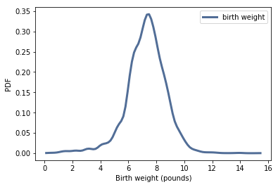

```python
birth_weights = live.totalwgt_lb.dropna()
pdf = thinkstats2.EstimatedPdf(birth_weights)
thinkplot.Pdf(pdf, label='birth weight')
thinkplot.Config(xlabel='Birth weight (pounds)', ylabel='PDF')
```

The mean is less than the median, which is consistent with left skew.

```python
Mean(birth_weights), Median(birth_weights)
```

```
(7.265628457623368, 7.375)
```

And both ways of computing skew are negative, which is consistent with left skew.

```python
Skewness(birth_weights), PearsonMedianSkewness(birth_weights)
```

```
(-0.5895062687577989, -0.23300028954731833)
```

## Adult weights

Now let's look at adult weights from the BRFSS. The distribution looks skewed to the right.

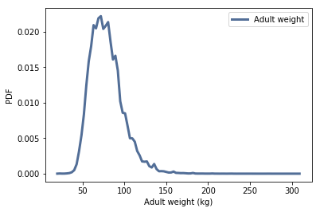

```python
adult_weights = df.wtkg2.dropna()
pdf = thinkstats2.EstimatedPdf(adult_weights)
thinkplot.Pdf(pdf, label='Adult weight')
thinkplot.Config(xlabel='Adult weight (kg)', ylabel='PDF')
```

The mean is greater than the median, which is consistent with skew to the right.

```python
Mean(adult_weights), Median(adult_weights)
```

```
(78.99245299687198, 77.27)
```

And both ways of computing skewness are positive.

```python
Skewness(adult_weights), PearsonMedianSkewness(adult_weights)
```

```
(1.054840012109306, 0.2643673381618039)
```

### Exercise

- Read NSFG respondent data with .ReadFemPreg() function that provided by nsfg.py and create a dataframe then assign it a variable that called preg.
  - Select 3 variables which are not relative each other and find their mean, median, variance, standard deviation and standard deviation.
  - Then plot the density function for each.
  - Then make a comment what you find.